# DataViz Makeover 1

My DataViz Makeover 1. Based on the assignment [here](https://isss608.netlify.app/dataviz/dataviz1)

Ng Yen Ngee https://www.linkedin.com/in/ng-yen-ngee/  
05-28-2021

## 1 Critique of Visualization

Original visualization can be seen below:

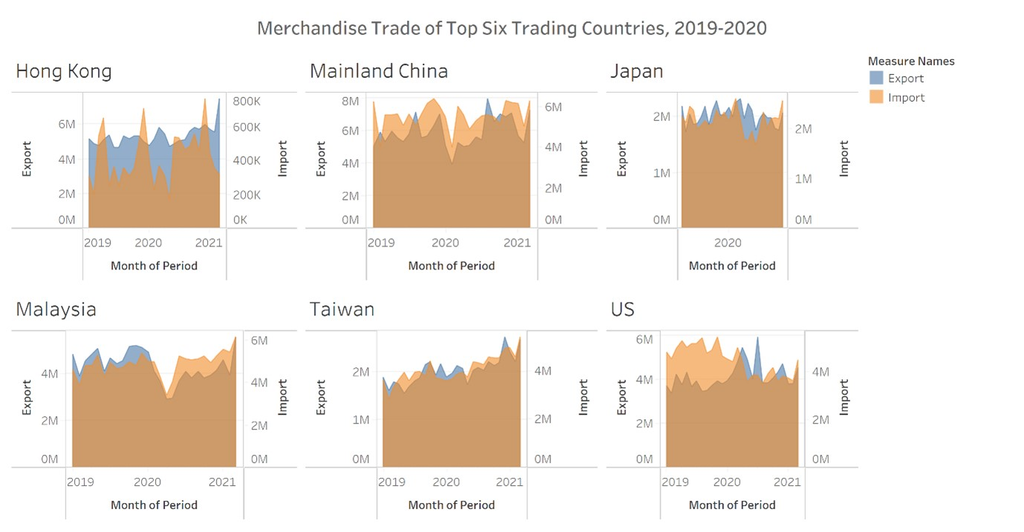

The original visualization has its own flaws. We will be critiquing them below:

### By Aesthetics

[output not shown]

### By Clarity

[output not shown]

## 2 Visualization Makeover

### Proposed Design

Considering that we want to minimize changes made to the original visualization as much as possible, the visualization has been redesigned as follows:

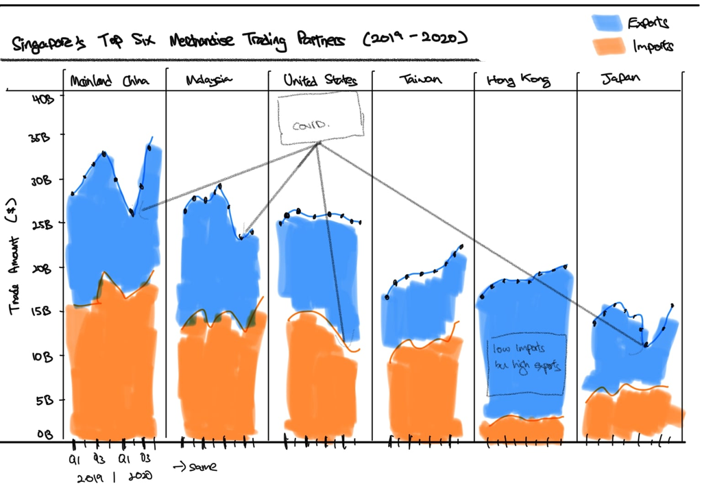

Below I will discuss the various key changes that has been made and explain why the changes were made and which critique in the earlier section did these changes overcome:

#### **Keeping area chart type but stacking them instead.**

As we are looking at Singapore’s top 6 merchandise trading partners and not just each countries’ export and import, it was decided to use stacked area chart to visualize the merchandise trade (sum of import and export) which shows the part to whole relationship well. Hence, we are also able to see the proportion of import and export relative to the sum of them like how Hong Kong has a very low import but actually has higher overall merchandise trade than that of Japan. This overcomes the issues raised in *C6* and *A5*.

#### **Using a single y-axis.**

One of the key confusing points in the original design was that the y-axis keeps changing for both imports and exports and for all six countries stated in *C3* and *C4*. Hence, in the proposed design, merchandise trade of each country shares the same y-axis on the left by placing all 6 countries on the same axis, dividing the visualization into 6 subplots horizontally instead of a 3 by 2 grid (discussed in *A3*). This also makes it easier to compare number across countries.

#### **Countries’ merchandise trade are ranked in descending order**

We know the top 6 trading countries, but do we know the country with the highest merchandise trade? Do we know out of the 6 countries, which country has the lowest trade? This was one of the critique made in *A4* which we corrected by adding the order in which the countries are placed so that we can see this ranking at a single glance.

#### **Using Quarterly data instead of monthly data**

Unfortunately, one drawback of using a single y-axis and comparing 6 countries like this in 6 horizontal subplots is that each subplot has limited x-axis space. If we were to show 2 years worth of monthly data, the level of detail shown by the area of chart would be too messy. Keeping in mind that we want to show Singapore’s top 6 trading partners across 2 years, it was decided that aggregating to quarterly data is sufficient to show just enough variation across time and yet not over complicate the visualization.

#### **Consistent x-axis range in each subplot.**

To solve *C1* and *C2*, we ensured that the axis in each subplot is of the same width, with the same range starting from 2019 Q1 to 2020 Q4.

#### **Other fixes**

Other fixes were made such as

- Ensuring that the visualization title has the largest font (*A1*)
- Adding annotations referring to certain portions of the graph to deliver insights more effectively (*A2*)
- Ensuring that y-axis and x-axis all have tick marks (*C5*)

### Proposed Visualization

The final proposed visualization is as follows:

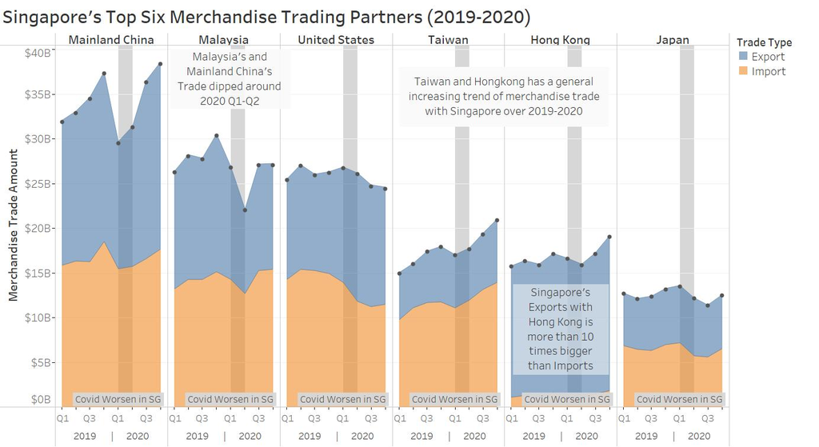

The visualization can also be access on [Tableau Public](https://public.tableau.com/app/profile/yen.ngee/viz/SingaporeTop6TradingPartners/SGTop6TradingPartners)

## 3. Step by Step Guide

In this portion, we will be running through the steps to create the final proposed visualization starting from loading and understanding the data, then we will run through what is done to prepare the data and finally creating the visualization on Tableau.

### Loading and Understanding the data

The Data obtained from the subsection of [Merchandise Trade by Region/Market](https://www.singstat.gov.sg/find-data/search-by-theme/trade-and-investment/merchandise-trade/latest-data) and was downloaded by clicking on the link Download all in Excel on the same web page.

Opening the Excel file we see that there are 3 tabs:

- Content – describes the content of the data in each page, hence we will not use this sheet.
- T1 – Merchandise Imports
- T2 – Merchandise Exports

[figure not shown]

On the top and bottom of the tab, there are notes which we would need to remove in our data preparation step. The header row starts from 6th row. There is data with countries represented by row and monthly data represented by columns. Looking at the first few rows, there are also aggregated such as Total Merchandise and regional data such as Asia(Million Dollars) which we will need to remove. Across the columns, we would also only need to extract data from 2019 Jan to 2020 Dec. T2 has a similar structure as T1 and will be prepared in a similar way.

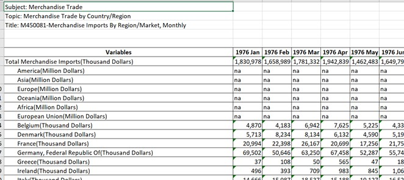

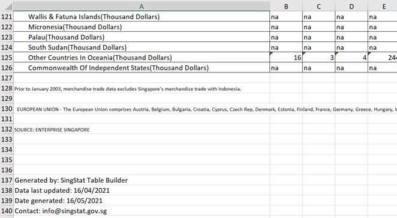

In our proposed visualization, we are looking at both exports and imports in a stacked area chart across time and country. Hence, we will need to prepare the data such that it is in a long format which makes it easier to manipulate in Tableau. The final form of the data should look something like this:

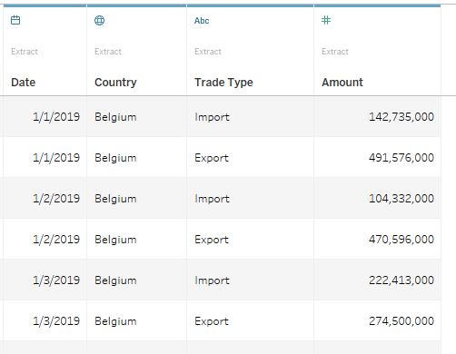

### Data Preparation

We will be using Tableau Prep Builder to prepare the data. Each step is explained carefully such that it can also be replicated using alternative means.

#### **Step 1: Connect to Data Source**

After opening Tableau Prep Builder Software, we first need to connect to the Data Source. In this case, we will connect to the excel file that was previously downloaded.

[figure not shown]

#### **Step 2: Add Data to Flow**

In the new interface, drag and drop T1 onto the working space on the right. Tableau Prep Builder will automatically load the data. However, we can see that it has also included the notes that we need to delete. Tableau has a handy button on the left called Use `Data Interpreter` which automatically extracts the table data without us having the manually delete the columns.

[figure not shown]

From there, if we right click on T1, we can choose various steps to treat the data. We will first clean the data.

[figure not shown]

#### **Step 3a: Clean T1 - filter the data**

At this step, our data looks like this.

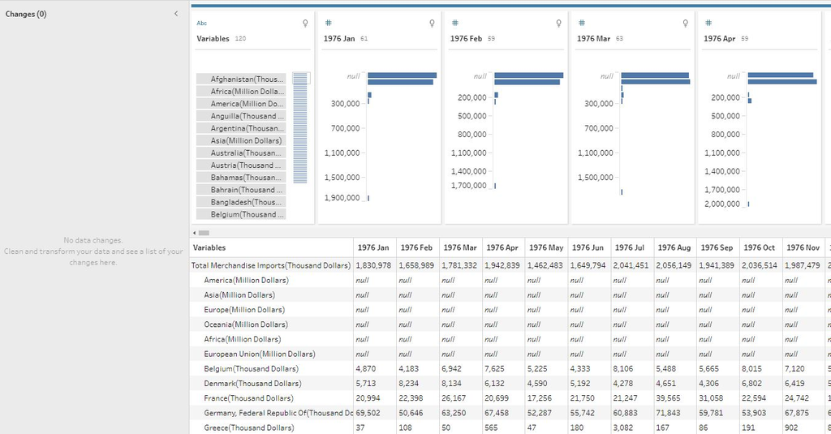

As mentioned in Loading and Understanding the data section, we need to exclude the aggregated data. Selecting the first 7 rows until “European Union (Million Dollars)”, we can right click and select `Exclude` to exclude these data. At the same time, our visualization only include data from 2019 to 2020. Hence, we select the columns from all other dates and select `Remove`. What is left is the Import data of all countries from 2019 to 2020.

Note: at this point, we could possibly only keep data from the 6 countries identified in the original visualization. It was just a personal choice to keep all of the data for now, so that we can do other visualization with all of the trade data for fun. ;)

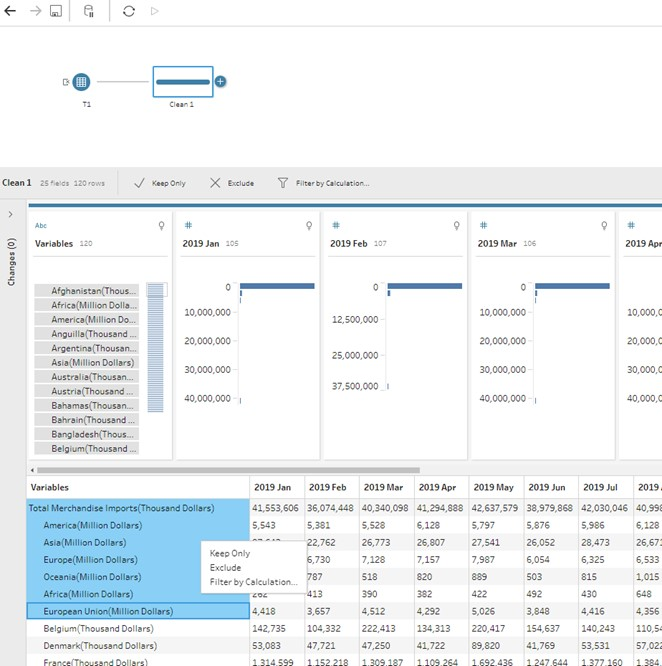

#### **Step 3b: Clean T1 - Split column to get country**

If we look under variables, we know that it is in the format of “white space” + “country name” + “(Thousand Dollars)”. We want to only extract the country name, keeping in mind the values are in thousands. Hence, if we click the 3 dots on the column, we can do an `Automatic split` which will extract country name. The original column is then removed as we do not need it and the new column name is changed to “Country”.

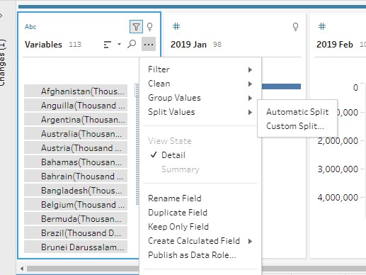

The data after this step should look like this:

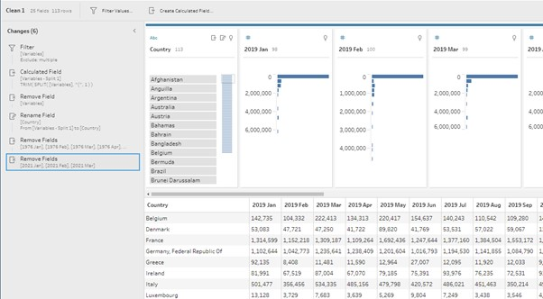

#### **Step 4: Pivot T1**

Next, we have to convert all the data in each column and pivot them into rows. To do so, we first select all the columns except for “Country”, and click on `Pivot Columns to Rows`.

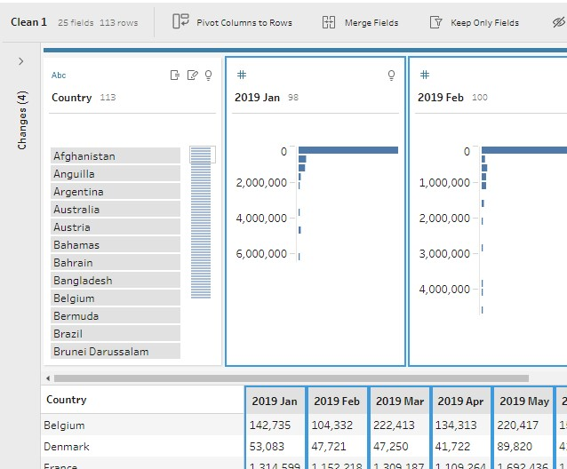

This will automatically create a pivot step where they will keep the “Country” as it is and create row with each row containing the value found within the original column. We rename “Pivot1 Names” as “Date” and “Pivot1 Values” as “Import (in thousand)”

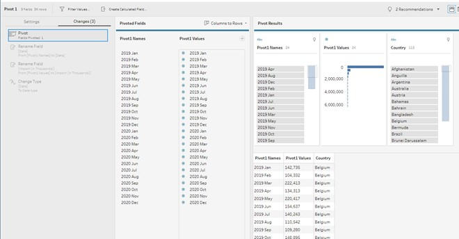

#### Repeat steps 2 to 4 for T2, except to rename the column after pivoting as “Export (in thousand)” since T2 has the same structure as T1.

#### **Step 5: Join Pivoted T1 and Pivoted T2**

Now we would like to combine the data set. There are different ways of doing this. However, I chose to inner join the two data sets on “Country” and “Date”. This means that the data left are countries that must have both imports and exports throughout the period of 2019 and 2020.

To do this, we simply drag `Pivot 2` over `Pivot 1` under the join option which will appear when you hover over it. This will be the result after removing the duplicated columns of “Date” and “Country”:

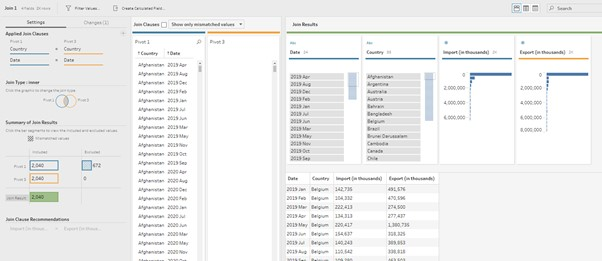

Note: a manual check confirms that the 6 countries that we are concerned with is part of this data set.

#### **Step 6: Clean**

At this point, it is easy to convert the “Import(in thousands)” and “Export(in thousands)” to the values multiply by 1000. Clicking the 3 dots, we select `Create Calculated Field`, then `Custom Calculation`.

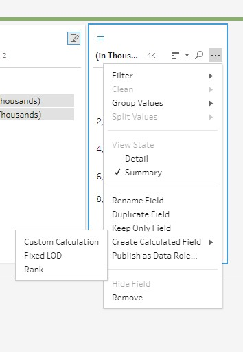

We’ll come to this pop up where we can key in our new column. We will follow the following formulas:

- Export = [Export(in thousands)] * 1000
- Import = [Import(in thousands)] * 1000

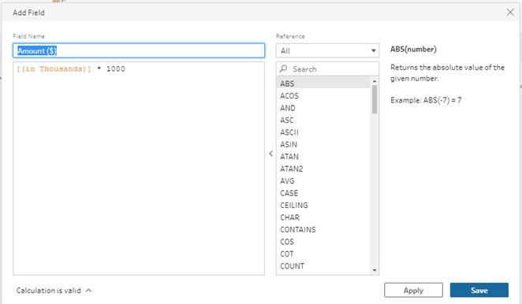

We remove the old columns and select the 2 new columns (“Import” & “Export”) and pivot them again.

#### **Step 7: Pivot + Final Clean**

We are very close to the final table that we need. We just need to do a final check on the column name data type and change them where necessary:

Here is the final table:

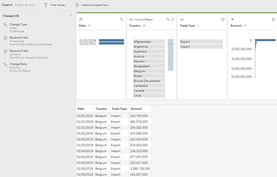

In the work space, we can also see the following work flow:

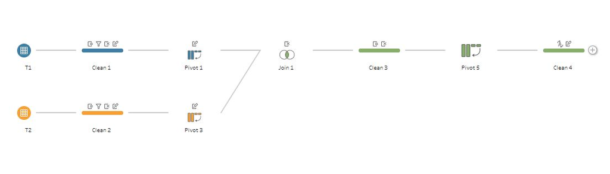

#### **Step 8: Output**

We could create an output node to output the data. However, Tableau Data Prep allows us to have a shortcut. By right-click on the last node and selecting `Preview in Tableau Desktop`, we can create the visualization directly.

### Create Visualization

We will be using Tableau Desktop to create the visualization and this section will provide a step by step guide to do so. Before we begin, it is always good to have cursory check on the data type. We see that “Country”, “Date” and Trade Type are dimensions while “Amount” is in Measure.

#### **Step 1:**

The first step is to drag and drop the data into our graph.

- Columns: we drag “Country” and “Date”
- Row: we drag “Amount”

Automatically, Tableau calculates the sum of the “Amount” which is exactly what we need. For “Date” it automatically selects the “Year” as an input dimension.

[figure not shown]

#### **Step 2:**

We can see from the screenshot above there are too many countries. Hence, we need to filter the data by “Country”. Drag and drop “Country” onto the Filter card next to the graph. A window will pop-up (see screenshot below). From there we will manually select the top 6 countries: United States, Malaysia, Hong Kong, Japan, Mainland China and Taiwan.

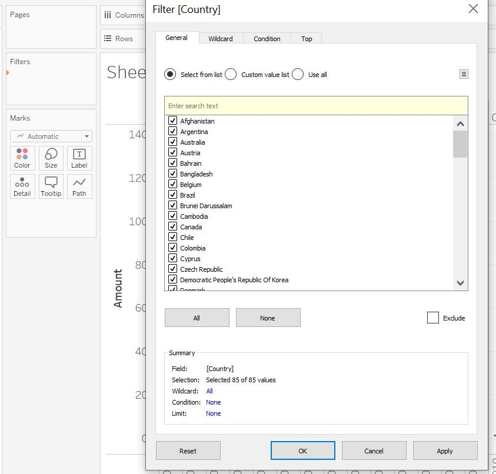

Results will look like this:

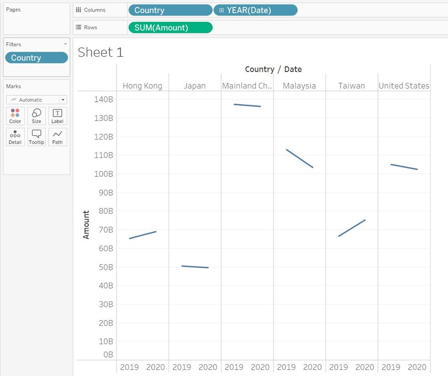

#### **Step 3:**

Now we have line charts of each countries’ total trade merchandise. However, we would like to split them into “Import” and “Export”. We drag “Trade Type” and drop them in `colour`. Tableau will split the data to 2 lines.

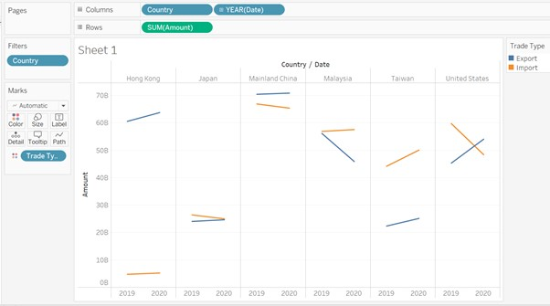

#### **Step 4:**

Tableau automatically churns out line graphs for us. However, following our proposed design, we want an area chart. On the left side under `Marks`, we can select `Area` in the drop down to turn this into an area chart.

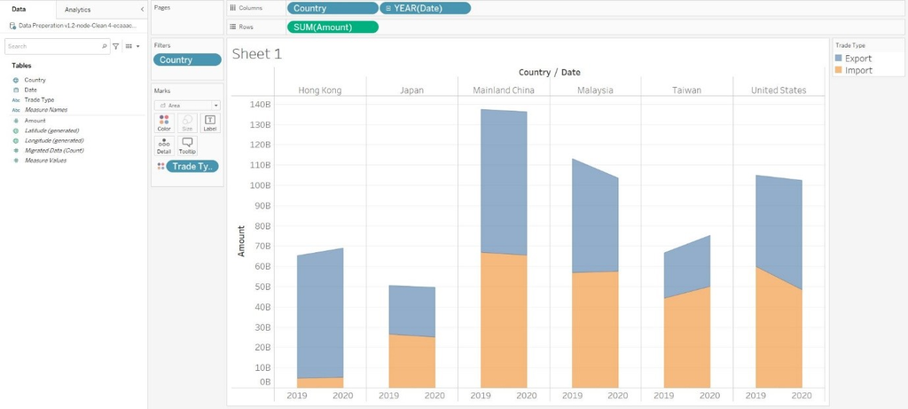

#### **Step 5:**

This shows the yearly data for each country but we want quarterly data. Hence clicking on the triangle in the “Year(Date)” on “Date”, we can select Quarter from the list. Note that we choose the Quarter in the lower section, this would give a measure rather than a dimension. This means that the area chart would be continuous within each countries’ subplot.

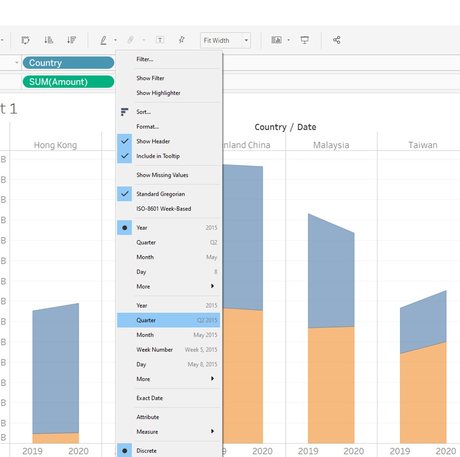

This is the result:

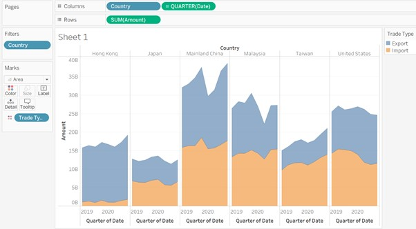

#### **step 6:**

Now we have the foundation of the visualization. Let’s sort them in descending order. Under the Filters card, we click the triangle button on “Country” and select sort. A window will pop-up and we need to select such that we are sorting by Field, in Descending Order, using the Field Name: Amount with Aggregation: Sum.

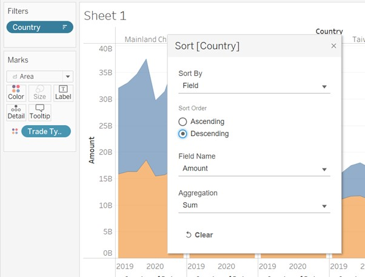

This is the result:

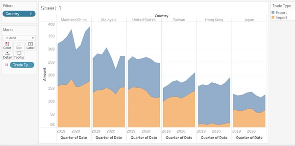

#### **Step 7:**

Let us now adjust the axis. For the y-axis, the values are in Billions with horizontal grid lines. All we need to do is to add the units to indicate dollars. So we right-click on the y-axis, and select format in the drop down. The formatting pane will appear on the left. Since we are formatting the Axis, we do not change the tab. Under the scale, we can format the Number selecting Currency [Custom]:

- Decimal places: 0
- Display Units: Billion (B)

The changes can be seen immediately on the y-axis:

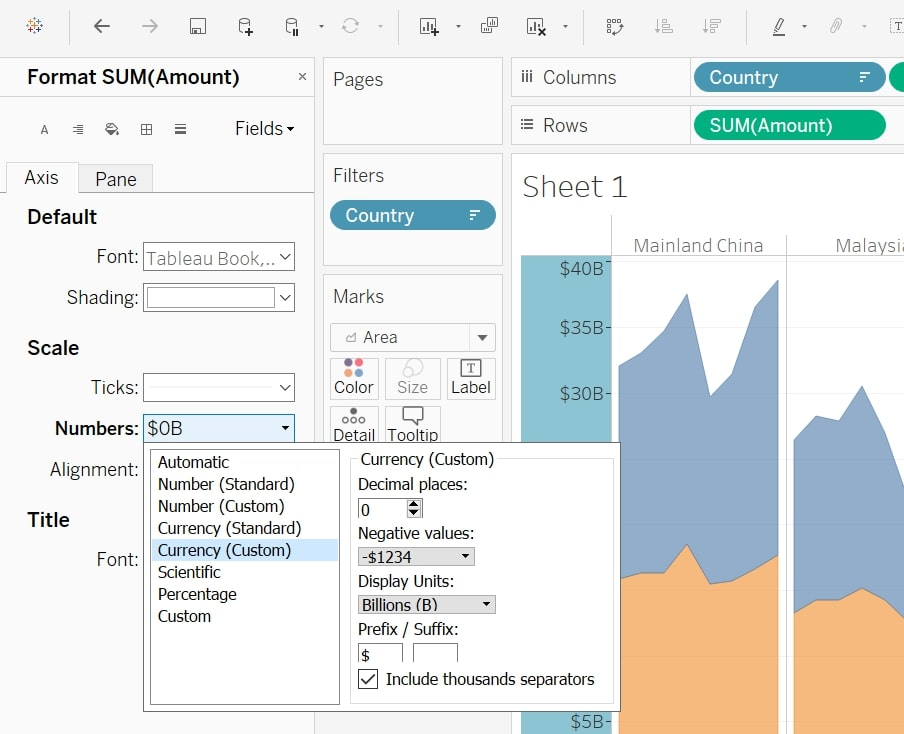